# GEOG 515 - spring 15: Introduction to R

This is an introduction to R. It describes basic operations of data input/output, making graphs and simple statistics.

## Getting Start

Some of R packages (i.e., libraries) are part of the basic installation. Others can be downloaded from CRAN which currently hosts over 1000 packages for various purposes. If you want to list all installed package, type:

#### library()

A package is loaded into R using the library command, so to load the “diagram” package you should enter:

#### library(diagram)

To list of functions in the diagram package with brief descriptions, enter:

### Examples of function option()

To view defaults, type:

#### options()

To know the default of the number of digits, type:

#### getOption(“digits”)

If you want to change the maximum number of digits printed from 7 (default) to 10, type:

#### options(digits=10)

### Using R as a calculator

```r
sqrt(16)+6^3
```

```
## [1] 220
```

```r
a=12^2
a
```

```
## [1] 144
```

### Vectors

```r
# Examples of creating vectors:
v1 <-  c(2.5, 4,  7.3, 0.1)
v2 <-  c("A", "B", "C", "D")
v3 <-  -3:3
v4<- seq(0,   2,  by=0.3)
v5<- seq(0,   2,  len=6)
v6<- rep(1:5, each=2)
v7<- rep(1:5,  times=2)
v1
```

```
## [1] 2.5 4.0 7.3 0.1
```

```r
v2
```

```
## [1] "A" "B" "C" "D"
```

```r
v3
```

```
## [1] -3 -2 -1  0  1  2  3
```

```r
v4
```

```
## [1] 0.0 0.3 0.6 0.9 1.2 1.5 1.8
```

```r
v5
```

```
## [1] 0.0 0.4 0.8 1.2 1.6 2.0
```

```r
v6
```

```
##  [1] 1 1 2 2 3 3 4 4 5 5
```

```r
v7
```

```
##  [1] 1 2 3 4 5 1 2 3 4 5
```

#### Examples of referencing vector elements

```r
x <-  c(4, 9,  2,  12,  11,  3)
x[4]
```

```
## [1] 12
```

```r
x[1:3]
```

```
## [1] 4 9 2
```

```r
x[c(2,5,6)]
```

```
## [1]  9 11  3
```

```r
x[-3]
```

```
## [1]  4  9 12 11  3
```

```r
x[-c(4,5)]
```

```
## [1] 4 9 2 3
```

```r
x[x>4]
```

```
## [1]  9 12 11
```

```r
x
```

```
## [1]  4  9  2 12 11  3
```

#### Examples of vector operations:

```r
x <-  c(2, 4, 6, 0)
y <-  x^2 + 1
y
```

```
## [1]  5 17 37  1
```

```r
x*y
```

```
## [1]  10  68 222   0
```

#### Example of matrix:

```r
x <-  matrix(c(1,2,3,4,5,6), nrow=2,  ncol=3, byrow=TRUE, dimnames=list(rows=c("row1", "row2"), cols=c("col1", "col2", "col3")))
x
```

```
##       cols
## rows   col1 col2 col3
##   row1    1    2    3
##   row2    4    5    6
```

#### Example of list:

```r
z <-  list(c(1,2,3), "Alisa", x)
z
```

```
## [[1]]
## [1] 1 2 3
##
## [[2]]
## [1] "Alisa"
##
## [[3]]
##       cols
## rows   col1 col2 col3
##   row1    1    2    3
##   row2    4    5    6
```

```r
z <-  list(num=c(1,2,3), name="Alisa", account=x)
z
```

```
## $num
## [1] 1 2 3
##
## $name
## [1] "Alisa"
##
## $account
##       cols
## rows   col1 col2 col3
##   row1    1    2    3
##   row2    4    5    6
```

#### Example of dataframe

```r
data()
data  <-  data.frame(chickwts)
data
```

```
##    weight      feed
## 1     179 horsebean
## 2     160 horsebean
## 3     136 horsebean
## 4     227 horsebean
## 5     217 horsebean
## 6     168 horsebean
## 7     108 horsebean
## 8     124 horsebean
## 9     143 horsebean
## 10    140 horsebean
## 11    309   linseed
## 12    229   linseed
## 13    181   linseed
## 14    141   linseed
```

[output cut: 57 more lines]

```r
head(data)       # Print the  first few rows
```

```
##   weight      feed
## 1    179 horsebean
## 2    160 horsebean
## 3    136 horsebean
## 4    227 horsebean
## 5    217 horsebean
## 6    168 horsebean
```

```r
tail(data)  # Print the  last few rowr
```

```
##    weight   feed
## 66    352 casein
## 67    359 casein
## 68    216 casein
## 69    222 casein
## 70    283 casein
## 71    332 casein
```

```r
names(data)     # Column names colnames(data); rownames(data)    # Column and row names
```

```
## [1] "weight" "feed"
```

```r
dim(data)   # Dimension of  the  dataframe
```

```
## [1] 71  2
```

```r
data[ ,c("weight",  "feed")]    # "weight" and "feed"  columns
```

```
##    weight      feed
## 1     179 horsebean
## 2     160 horsebean
## 3     136 horsebean
## 4     227 horsebean
## 5     217 horsebean
## 6     168 horsebean
## 7     108 horsebean
## 8     124 horsebean
## 9     143 horsebean
## 10    140 horsebean
## 11    309   linseed
## 12    229   linseed
## 13    181   linseed
## 14    141   linseed
```

[output cut: 57 more lines]

```r
data$weight     # Get the  column "weight"
```

```
##  [1] 179 160 136 227 217 168 108 124 143 140 309 229 181 141 260 203 148 169 213
## [20] 257 244 271 243 230 248 327 329 250 193 271 316 267 199 171 158 248 423 340
## [39] 392 339 341 226 320 295 334 322 297 318 325 257 303 315 380 153 263 242 206
## [58] 344 258 368 390 379 260 404 318 352 359 216 222 283 332
```

```r
data[1:5, ] # Get the  first five rows
```

```
##   weight      feed
## 1    179 horsebean
## 2    160 horsebean
## 3    136 horsebean
## 4    227 horsebean
## 5    217 horsebean
```

#### # Example of importing data into R

```r
setwd("C:/Liem/GEOG515/Spring15/Labs/")
getwd()
```

```
## [1] "C:/Liem/GEOG515/Spring15/Labs"
```

```r
data  <-  read.table("DuhramNCdata.txt", header=TRUE,  sep="\t")
str(data) # Gives  the  structure of  data
```

```
## 'data.frame':    193 obs. of  97 variables:
##  $ OBJECTID  : int  1 2 3 4 5 6 7 8 9 10 ...
##  $ Block_Grou: num  3.71e+11 3.71e+11 3.71e+11 3.71e+11 3.71e+11 ...
##  $ NO2_Hospit: num  105.6 166.5 215.2 152.6 61.7 ...
##  $ NO2_Asthma: num  2.166 3.414 3.424 2.429 0.824 ...
##  $ NO2_Asth_1: num  181.6 286.3 286.3 203.1 68.7 ...
##  $ O3_Acute_R: num  2.5 3.94 4.86 3.45 1.72 ...
##  $ O3_Mortali: num  8737 13772 16983 12048 5218 ...
##  $ O3_School_: num  1.151 1.815 1.793 1.272 0.433 ...
##  $ O3_School1: num  113.1 178.2 176 124.9 42.5 ...
##  $ PM25_Acute: num  1.337 2.107 2.619 1.858 0.977 ...
##  $ PM25_Morta: num  27121 42753 54756 38844 19114 ...
##  $ PM25_Work_: num  0.231 0.364 0.452 0.321 0.169 ...
##  $ PM25_Work1: num  38.8 61.1 76 53.9 28.3 ...
##  $ SO2_Asthma: num  0.1565 0.2467 0.2749 0.185 0.0663 ...
```

[output cut: 83 more lines]

```r
# Load data  using  file.choose()
# data  <-  read.table(file.choose(), header=TRUE,  sep="\t")

# Load a csv file:
# read.csv(file.choose(), dec='.', sep=',')
```

### Simple summary statistics

```r
dry <- c(77, 93, 92, 68, 88, 75, 100)
dry
```

```
## [1]  77  93  92  68  88  75 100
```

```r
sum(dry)
```

```
## [1] 593
```

```r
length(dry)
```

```
## [1] 7
```

```r
mean(dry)
```

```
## [1] 84.71429
```

```r
sum(dry)/length(dry) ## Checking
```

```
## [1] 84.71429
```

```r
median(dry)
```

```
## [1] 88
```

```r
sd(dry)
```

```
## [1] 11.54288
```

```r
var(dry)
```

```
## [1] 133.2381
```

```r
sd(dry)^2
```

```
## [1] 133.2381
```

```r
sum((dry-mean(dry))^2) / (length(dry)-1) ## Checking
```

```
## [1] 133.2381
```

```r
min(dry)
```

```
## [1] 68
```

```r
max(dry)
```

```
## [1] 100
```

```r
summary(dry)
```

```
##    Min. 1st Qu.  Median    Mean 3rd Qu.    Max.
##   68.00   76.00   88.00   84.71   92.50  100.00
```

#### Basic Scatterplot

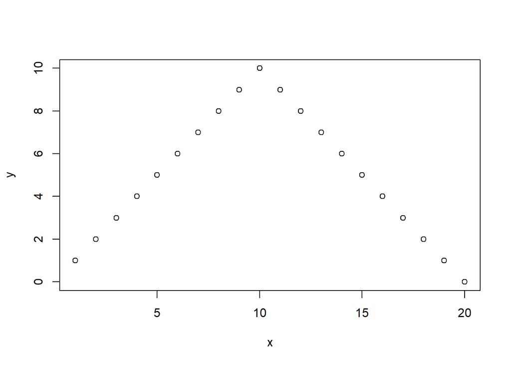

```r
x <-  c(1:20)
y <-  c(1:10,9:0)
plot(x, y)
```

#### Add some features:

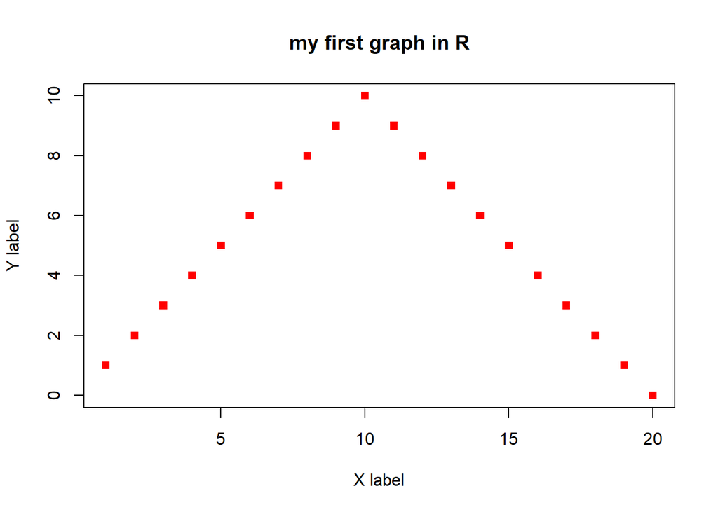

```r
plot(x,  y, xlab="X label", ylab="Y label", main="my first graph in R",  pch=15,  col="red")
```

#### And more features:

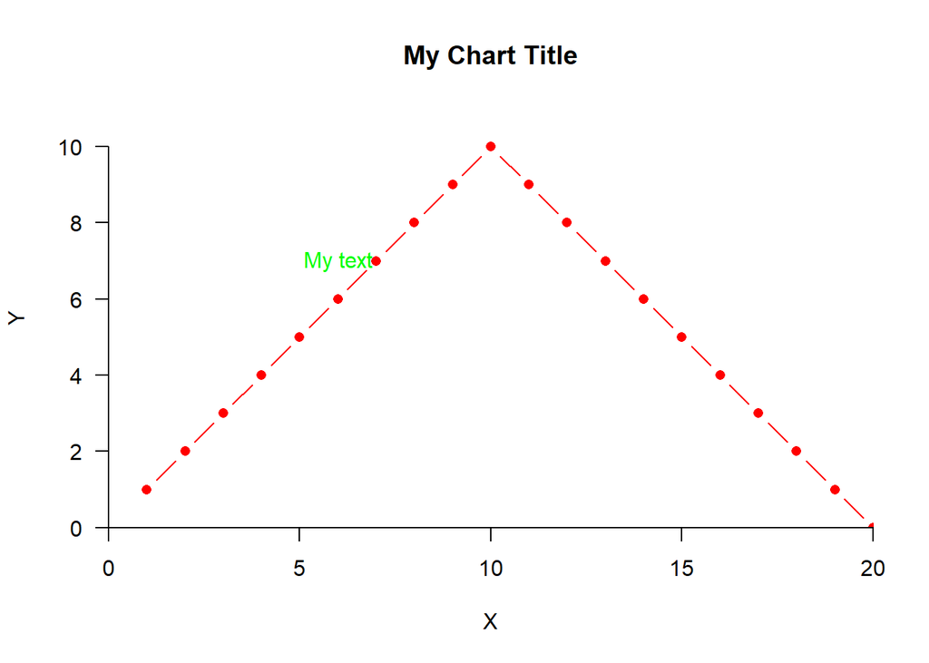

```r
plot(x, y,  main = "My Chart Title", type = "b", xlim = c(0,20),
     ylim = c(0,11), xlab ="X", ylab = "Y", pch=16,   col = "red",
     bty = "n", xaxs="i", yaxs = "i",   las=1)
# Add text:
text(6,7, "My text", col = "green" )
```

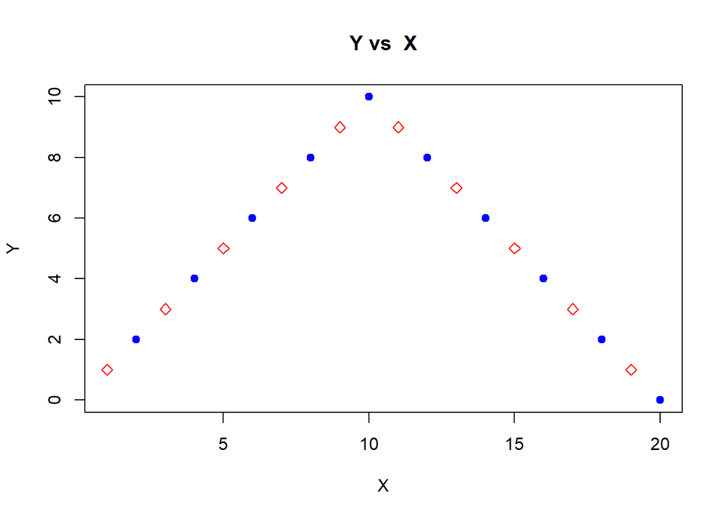

```r
# Distinguish between two separate  groups
plot(x,  y, xlab="X", ylab="Y", main="Y vs  X",
     pch=ifelse(x%%2==1, 5,  19),
     col=ifelse(x%%2==1, "red", "blue"))

## Example of 0uter Margin annotation
my_date <- format(Sys.time(), "%m/%d/%y")
my_text <-"manuscript 1"
mtext(my_text, side = 1, line = .75, cex=0.7, outer = T, adj = 0)
mtext(my_date, side = 1, line =.75, cex = 0.7, outer = T, adj = 1)
```

#### Basic Line Graphs

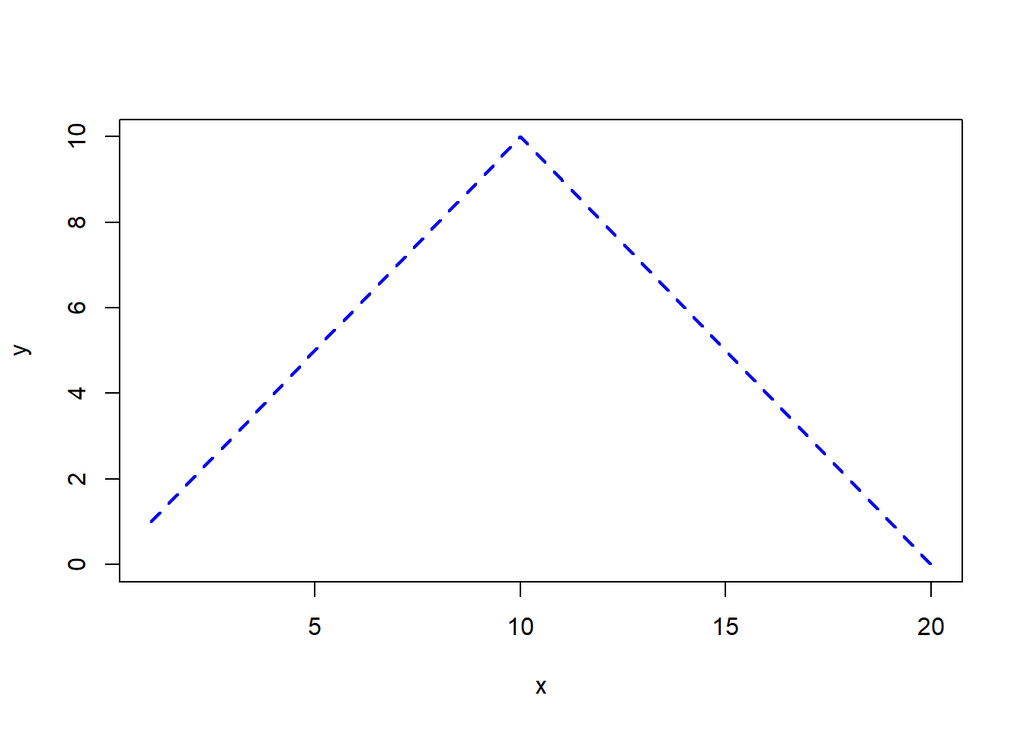

```r
plot(x, y, type="l", lty=2, lwd=2,  col="blue")
```

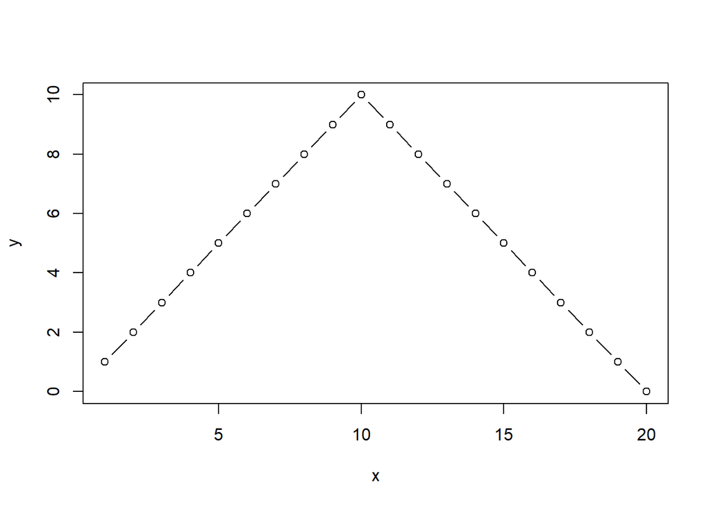

```r
# The  lines argument can be,  (1) two separate  vectors
# where one vector is the  x-coordinates and the  other   is the
# y-coordinates (2) a two-column  matrix or  (3) a two-element  list
# with  x and y components.
plot(x,  y, type="n")
lines(x, y, type="b")
```

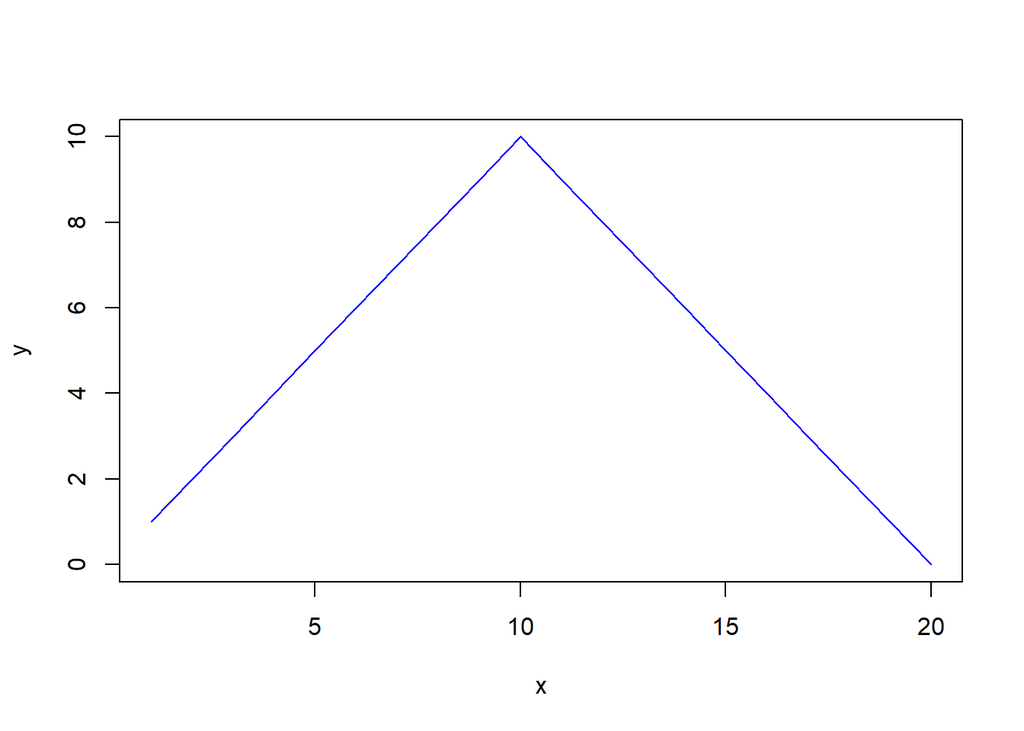

```r
plot(x,  y, type="n")
lines(cbind(x,y),  type="l", lty=1, col="blue")
```

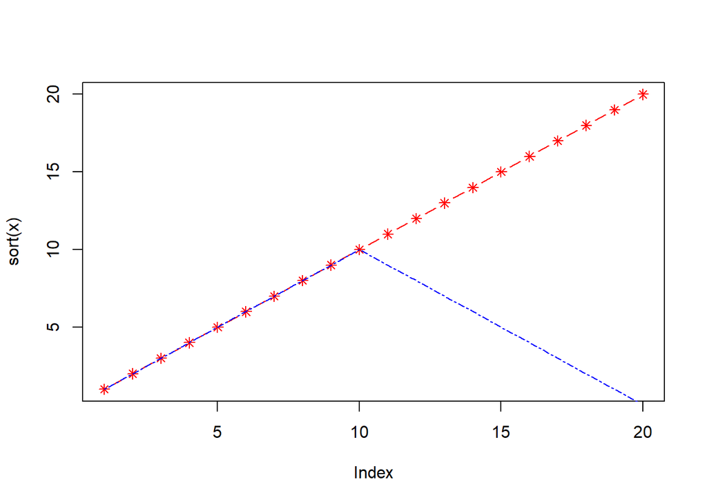

```r
# If there   is only  one component then  the  argument is plotted against
# its index  (same with  plot and points)
plot(sort(x),  type="n")
lines(x, type="b", pch=8,  col="red")
lines(y,  type="l", lty=6, col="blue")
```

#### Example of adding lines in plot area

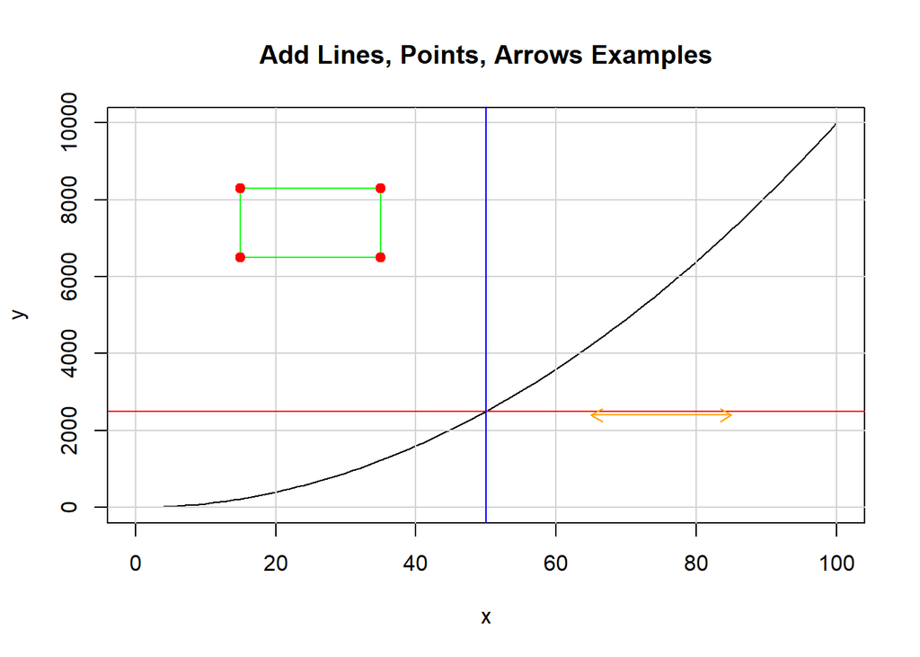

```r
x <- 0:100
y <- x^2
x_pts <- c(15, 35, 35, 15, 15)
y_pts <- c(8300, 8300, 6500, 6500,8300)
plot(x,y, type = "n", main="Add Lines, Points, Arrows Examples")
points(x, y,col = "black", lty=1, type = "l")
grid(col="lightgrey", lty=1)
abline(h=2500, col="red")
abline(v=50, col = "blue")
arrows(65,2400, 85,2400, code=3,  col="orange", length = 0.1)
lines(x_pts, y_pts, lty=1, col = "green")
points(x_pts,y_pts, type = "p",  col ="red",pch=19)
```

### More Graphical Tools with R

```r
# now we use the trees dataset in R
data<- trees
data
```

```
##    Girth Height Volume
## 1    8.3     70   10.3
## 2    8.6     65   10.3
## 3    8.8     63   10.2
## 4   10.5     72   16.4
## 5   10.7     81   18.8
## 6   10.8     83   19.7
## 7   11.0     66   15.6
## 8   11.0     75   18.2
## 9   11.1     80   22.6
## 10  11.2     75   19.9
## 11  11.3     79   24.2
## 12  11.4     76   21.0
## 13  11.4     76   21.4
## 14  11.7     69   21.3
```

[output cut: 17 more lines]

The trees dataset has three fields: Girth, Height, and Volume. There are different ways to use the fields of the trees dataset: . Attach the dataset as a data frame: attach(trees) (we learned this way last week) . Use the “data=trees” syntax, . Wrap the command in the “with” command, or . Use the syntax dataset$field for each variable.

The following commands will produce the same result:

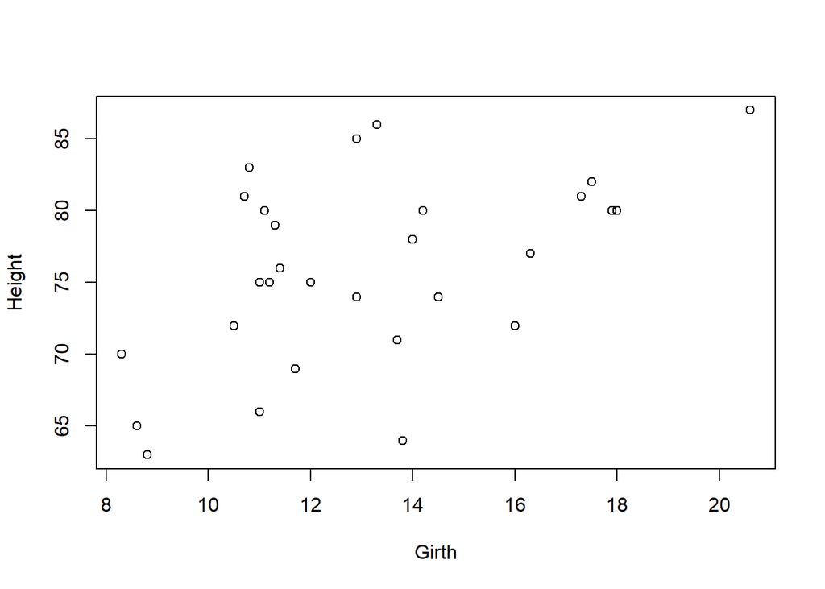

```r
#Pay attention to the labels of the x and y axes.
plot(Height~Girth, data=trees)       # you do not need to "attach" "trees" before this command
with(trees, plot(Height~Girth))   # you do not need to "attach" "trees" before this command
```

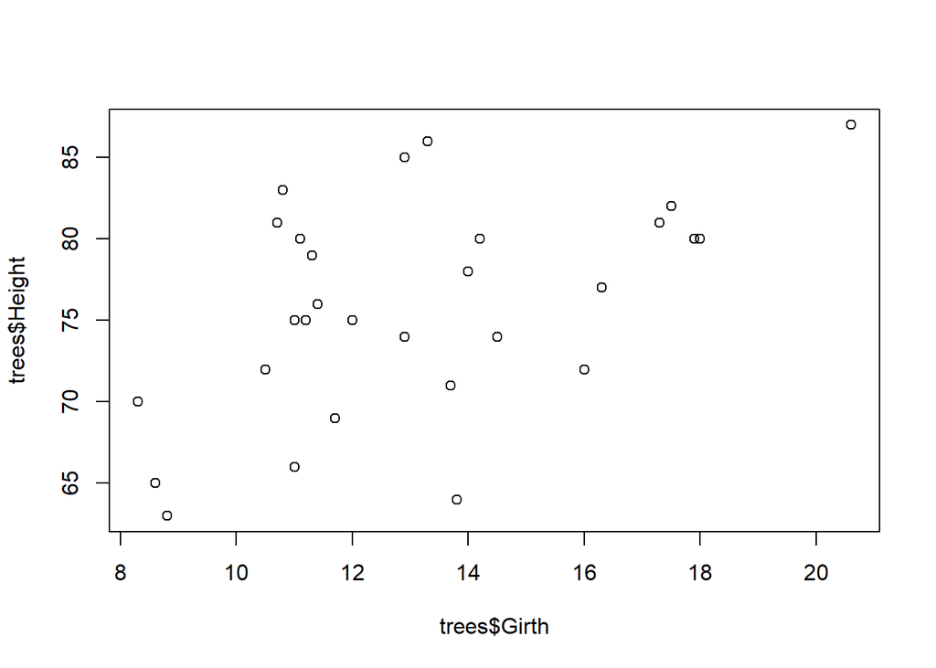

```r
plot(trees$Girth, trees$Height)
```

Now try this command:

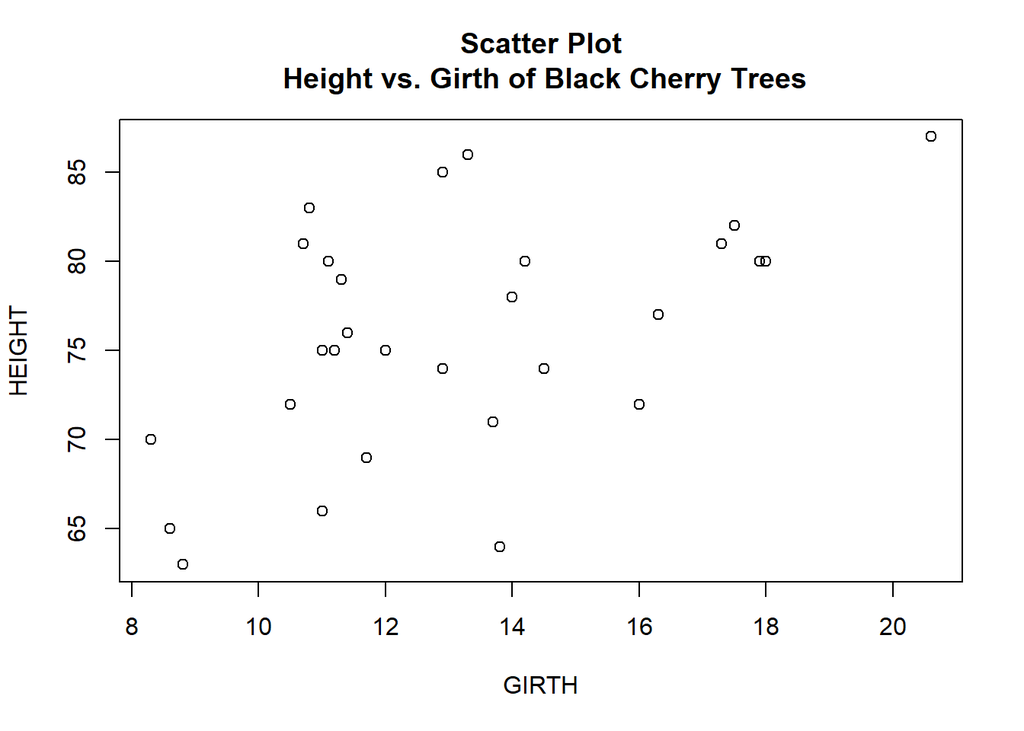

```r
plot(Height ~Girth, data=trees, xlab= "GIRTH", ylab= "HEIGHT",main=  "Scatter Plot\n Height vs. Girth of Black Cherry Trees")
```

```r
# Compare the labels with those in the previous plot and pay attention to the plot title. (\n: go to the next line).
```

Now we use the swiss dataset. Try and observe the output:

```r
swiss
```

```
##              Fertility Agriculture Examination Education Catholic
## Courtelary        80.2        17.0          15        12     9.96
## Delemont          83.1        45.1           6         9    84.84
## Franches-Mnt      92.5        39.7           5         5    93.40
## Moutier           85.8        36.5          12         7    33.77
## Neuveville        76.9        43.5          17        15     5.16
## Porrentruy        76.1        35.3           9         7    90.57
## Broye             83.8        70.2          16         7    92.85
## Glane             92.4        67.8          14         8    97.16
## Gruyere           82.4        53.3          12         7    97.67
## Sarine            82.9        45.2          16        13    91.38
## Veveyse           87.1        64.5          14         6    98.61
## Aigle             64.1        62.0          21        12     8.52
## Aubonne           66.9        67.5          14         7     2.27
## Avenches          68.9        60.7          19        12     4.43
## Cossonay          61.7        69.3          22         5     2.82
## Echallens         68.3        72.6          18         2    24.20
## Grandson          71.7        34.0          17         8     3.30
## Lausanne          55.7        19.4          26        28    12.11
## La Vallee         54.3        15.2          31        20     2.15
## Lavaux            65.1        73.0          19         9     2.84
## Morges            65.5        59.8          22        10     5.23
## Moudon            65.0        55.1          14         3     4.52
## Nyone             56.6        50.9          22        12    15.14
## Orbe              57.4        54.1          20         6     4.20
## Oron              72.5        71.2          12         1     2.40
## Payerne           74.2        58.1          14         8     5.23
## Paysd'enhaut      72.0        63.5           6         3     2.56
## Rolle             60.5        60.8          16        10     7.72
## Vevey             58.3        26.8          25        19    18.46
## Yverdon           65.4        49.5          15         8     6.10
## Conthey           75.5        85.9           3         2    99.71
## Entremont         69.3        84.9           7         6    99.68
## Herens            77.3        89.7           5         2   100.00
## Martigwy          70.5        78.2          12         6    98.96
## Monthey           79.4        64.9           7         3    98.22
## St Maurice        65.0        75.9           9         9    99.06
## Sierre            92.2        84.6           3         3    99.46
## Sion              79.3        63.1          13        13    96.83
## Boudry            70.4        38.4          26        12     5.62
```

[output cut: 41 more lines]

```
## Herens                   18.3
## Martigwy                 19.4
## Monthey                  20.2
## St Maurice               17.8
## Sierre                   16.3
## Sion                     18.1
## Boudry                   20.3
## La Chauxdfnd             20.5
## Le Locle                 18.9
## Neuchatel                23.0
## Val de Ruz               20.0
## ValdeTravers             19.5
## V. De Geneve             18.0
## Rive Droite              18.2
## Rive Gauche              19.3
```

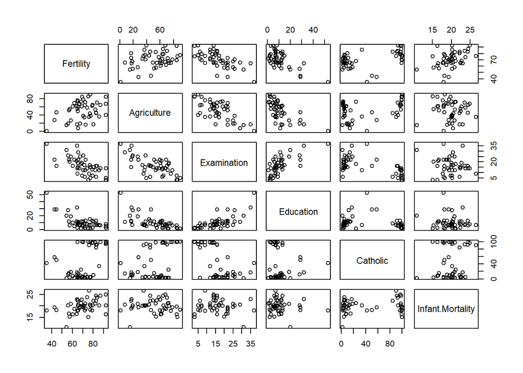

```r
plot(swiss)
```

Now try and compare the two graphs below:

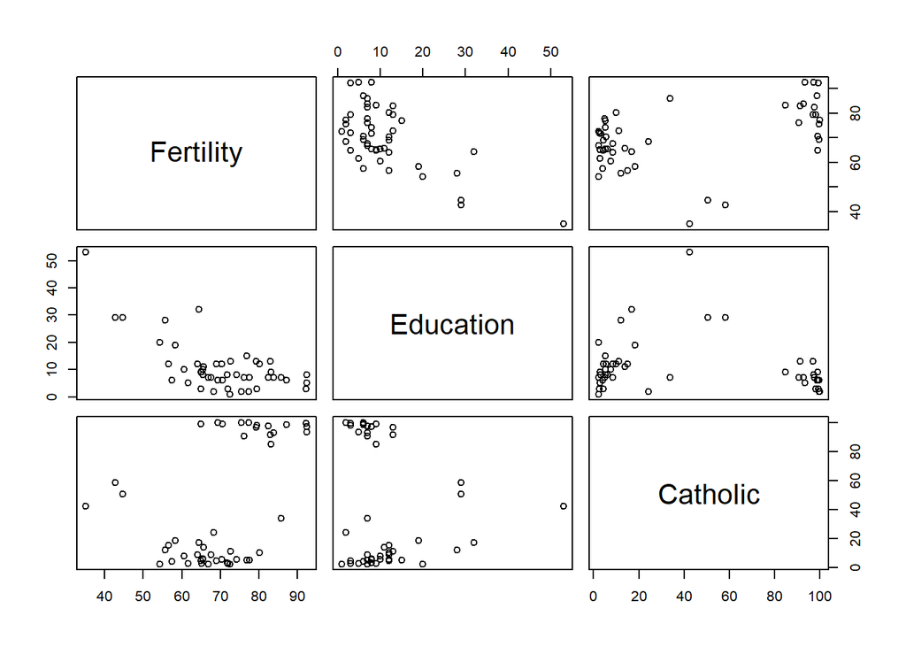

```r
plot(~ Fertility + Education + Catholic, data = swiss)
```

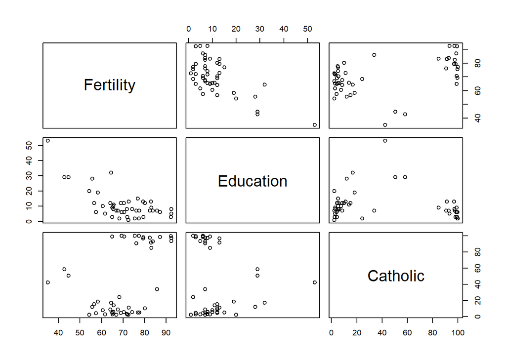

```r
pairs(~ Fertility + Education + Catholic, data = swiss)
```

Try these to see how to add a fitted curve to a scatter plot:

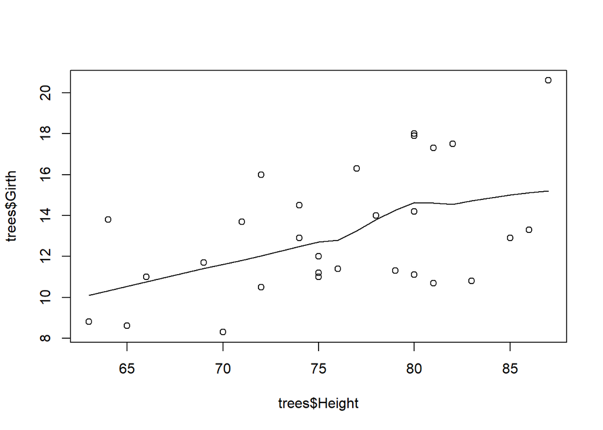

```r
plot(trees$Height,trees$Girth)
 lines(lowess(trees$Girth~trees$Height))
```

Plot two scatter plots on the same graph:

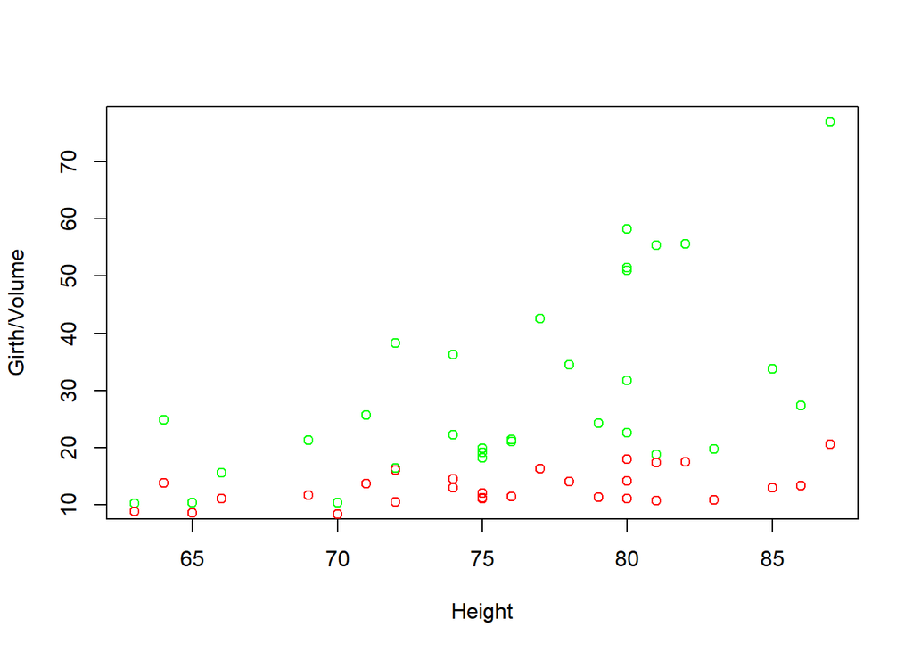

```r
plot(trees$Volume~trees$Height,col="green",xlab="Height",ylab="Girth/Volume")
points(trees$Girth~trees$Height,col="red")   # "points" adds a new series to an existing graph
```

### Barplot

Now we use the VADeaths dataset (Death Rates in Virginia (1940)). Type the following functions and compare the graphs (delete each graph before typing the next function.

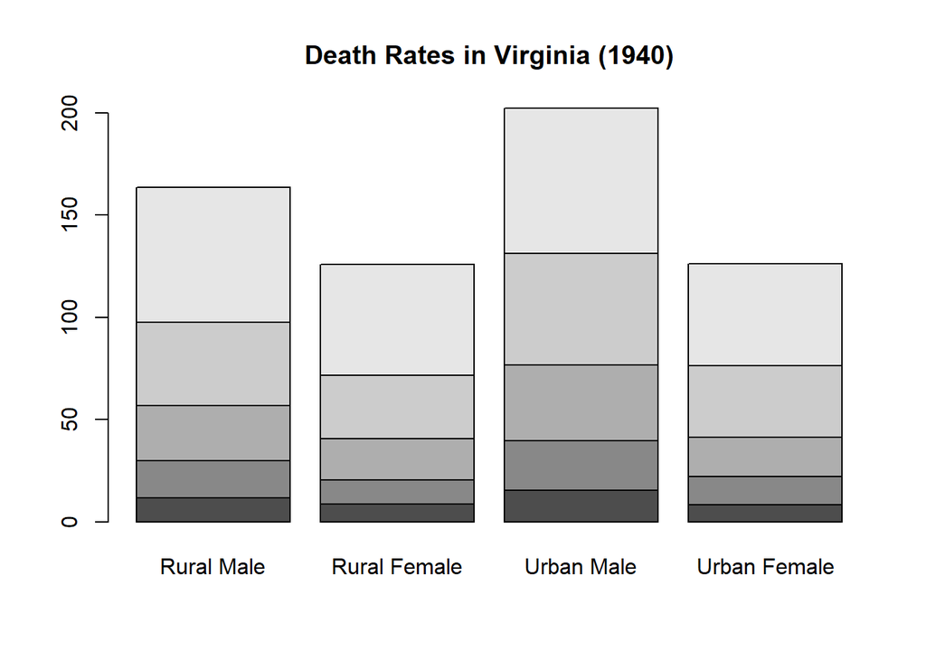

```r
barplot(VADeaths, main="Death Rates in Virginia (1940)")
```

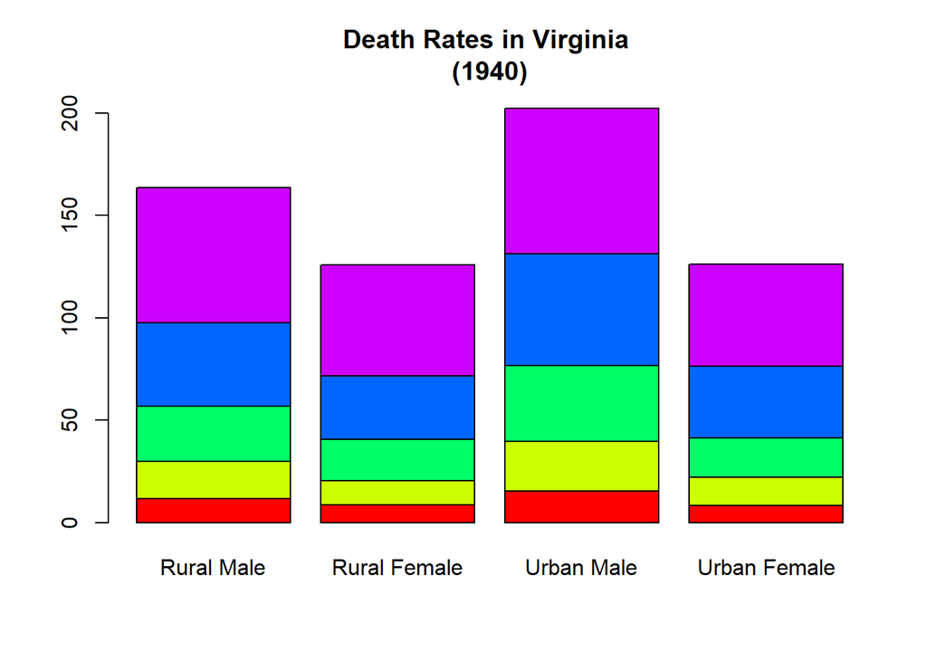

```r
barplot(VADeaths,col=rainbow(5), main="Death Rates in Virginia \n(1940)")
```

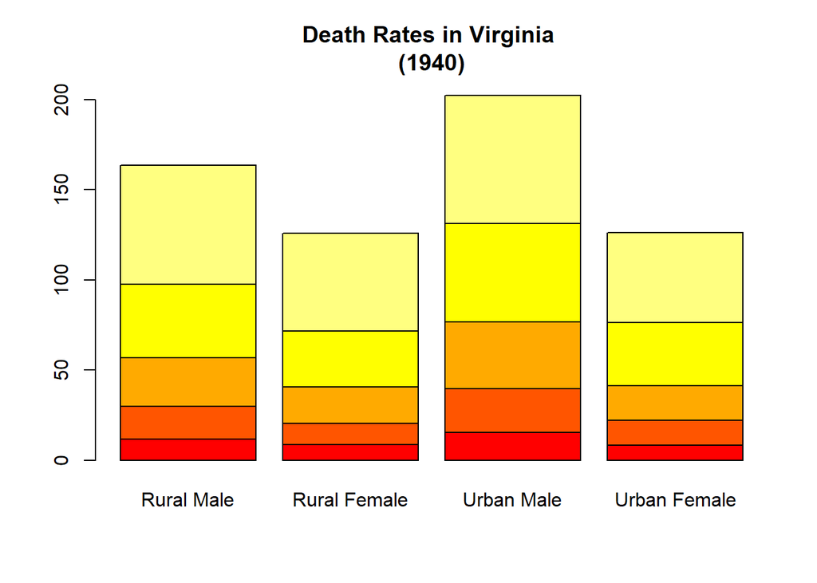

```r
barplot(VADeaths,col= heat.colors(5), main="Death Rates in Virginia \n(1940)")
```

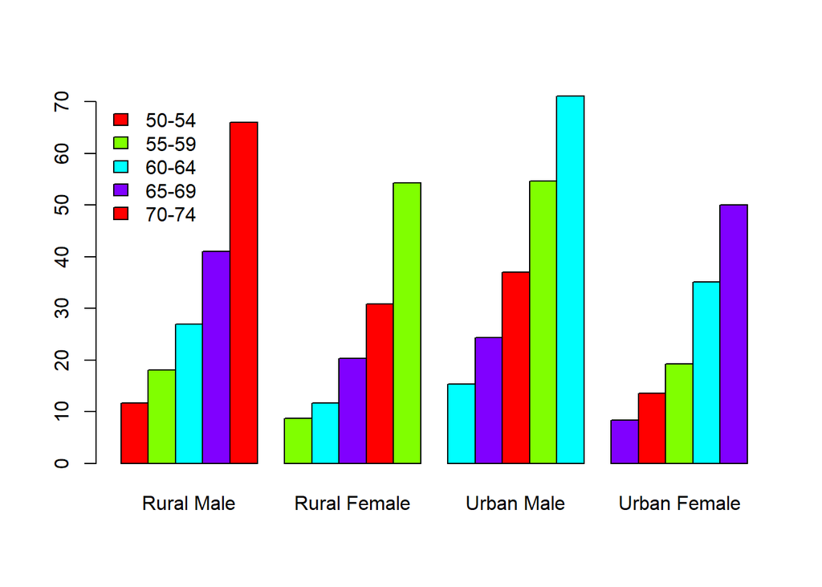

```r
barplot(VADeaths,beside=TRUE,col=rainbow(4))
legend("topleft",  cex=1.0,rownames(VADeaths),bty="n", fill=rainbow(4))
```

Delete the graph and try:

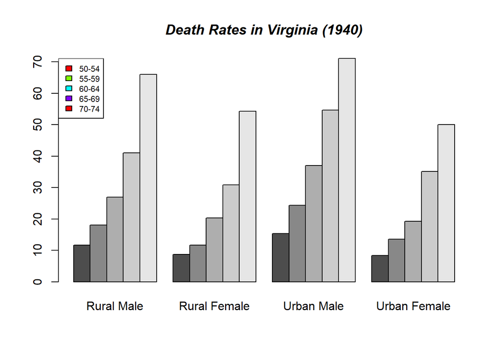

```r
barplot(VADeaths, beside=TRUE)
legend("topleft",  cex=0.7,rownames(VADeaths),bty="y", fill=rainbow(4))
title(main = list("Death Rates in Virginia (1940)", font = 4))
```

### Boxplot

A box plot is the standard box and whiskers plot. Usage: boxplot(x, …) x can be a vector or a formula (y ~ grp), where grp is a factor. Now we use the chickwts dataset with two fields: weight and feed.

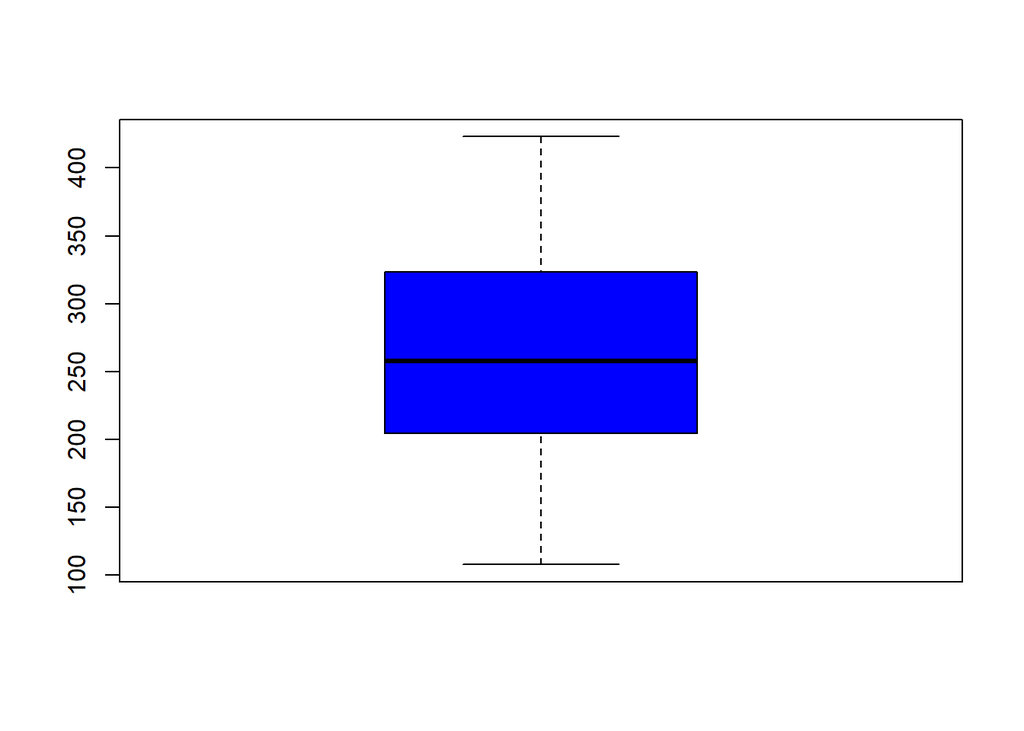

```r
boxplot(chickwts$weight,col="blue")
```

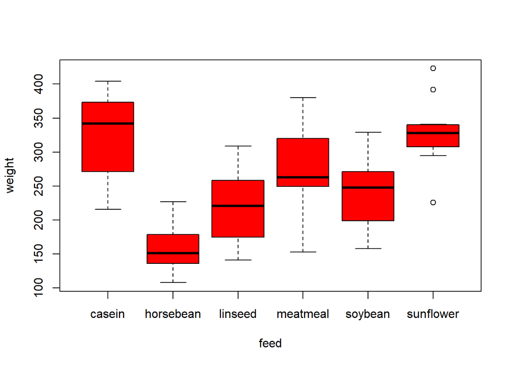

```r
boxplot(weight ~ feed, data=chickwts, col="red")
```

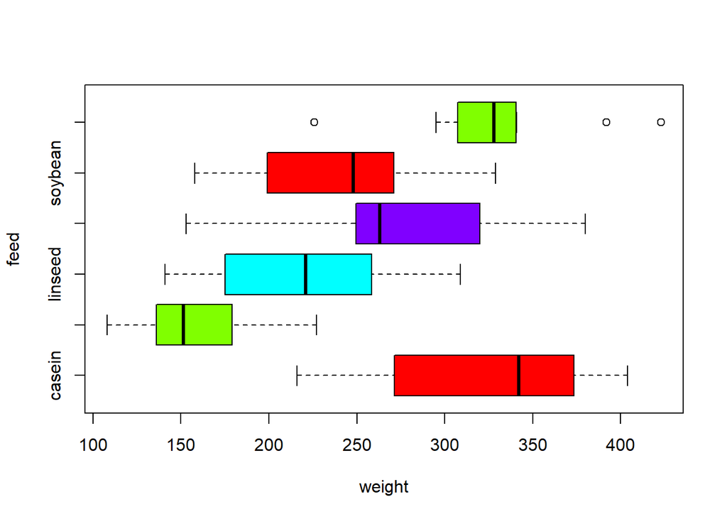

```r
boxplot(weight ~ feed, data=chickwts, col=rainbow(4), horizontal=TRUE)
```

### Histogram

The function hist() computes a histogram of the given data values: hist(x, …) x is the vector of values to be in the histogram.

```r
hist(chickwts$weight, plot=FALSE)
```

```
## $breaks
## [1] 100 150 200 250 300 350 400 450
##
## $counts
## [1]  7 10 16 12 17  7  2
##
## $density
## [1] 0.0019718310 0.0028169014 0.0045070423 0.0033802817 0.0047887324
## [6] 0.0019718310 0.0005633803
##
## $mids
## [1] 125 175 225 275 325 375 425
##
## $xname
## [1] "chickwts$weight"
##
## $equidist
## [1] TRUE
##
## attr(,"class")
## [1] "histogram"
```

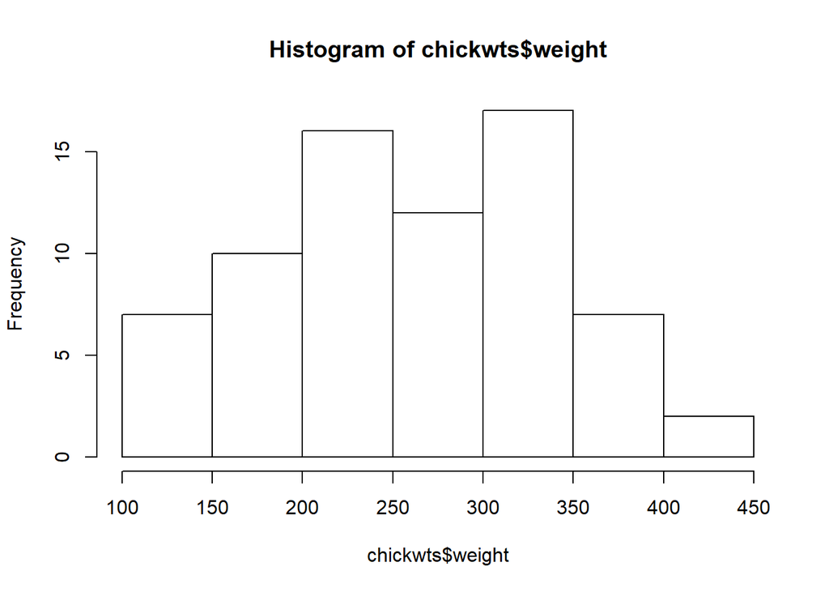

```r
hist(chickwts$weight, plot=TRUE)
```

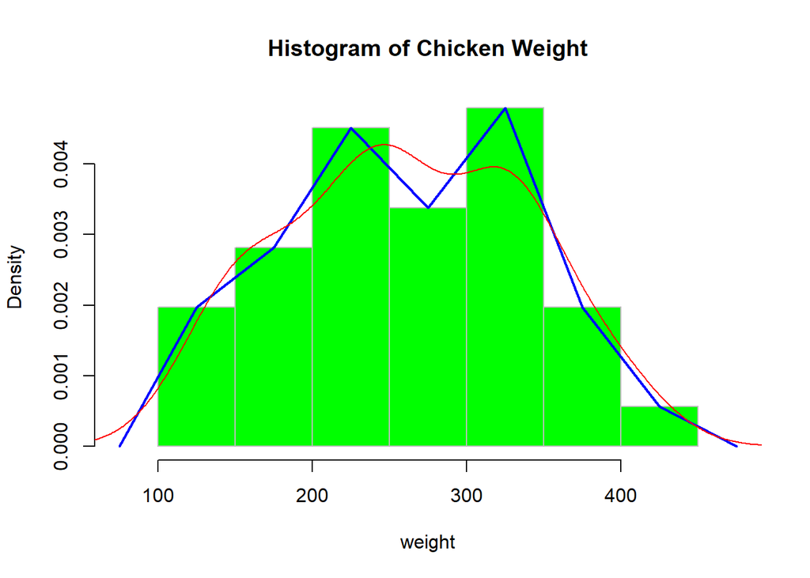

```r
h<- hist(chickwts$weight, plot=FALSE)

# compute the frequency polygon
diffBreaks <- h$mids[2] - h$mids[1]
xx <- c( h$mids[1]-diffBreaks, h$mids, tail(h$mids,1)+diffBreaks )
yy <- c(0, h$density, 0)
# draw the histogram
hist(chickwts$weight, prob = TRUE, xlim=range(xx), border="gray", col="green",xlab="weight",main="Histogram of Chicken Weight")
# adds the frequency polygon
lines(xx, yy, lwd=2, col = "blue")
# adds the densily curve if you want
lines(density(chickwts$weight),col="red")
```

###Pie charts

function pie(x, …) Example:

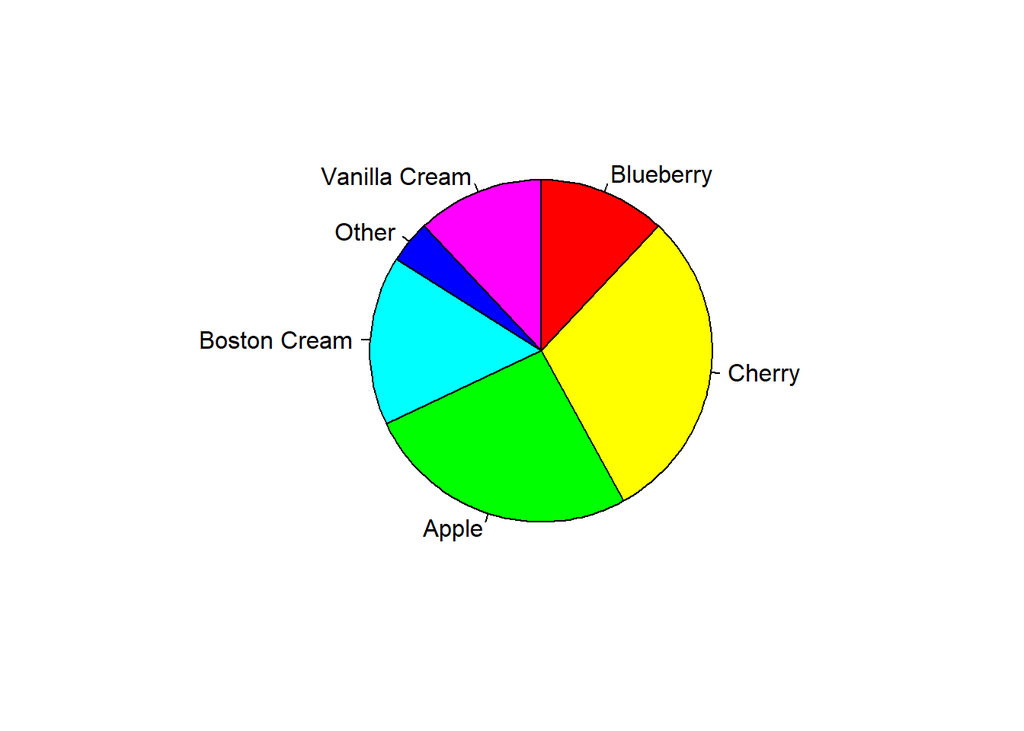

```r
sales <- c(0.12, 0.3, 0.26, 0.16, 0.04, 0.12)
names<- c("Blueberry", "Cherry", "Apple", "Boston Cream", "Other", "Vanilla Cream")
pie(sales,labels=names,col=rainbow(length(names)), clockwise=TRUE)
```

### Line Chart

We will use the Orange dataset in R

```r
Orange
```

```
##    Tree  age circumference
## 1     1  118            30
## 2     1  484            58
## 3     1  664            87
## 4     1 1004           115
## 5     1 1231           120
## 6     1 1372           142
## 7     1 1582           145
## 8     2  118            33
## 9     2  484            69
## 10    2  664           111
## 11    2 1004           156
## 12    2 1231           172
## 13    2 1372           203
## 14    2 1582           203
```

[output cut: 21 more lines]

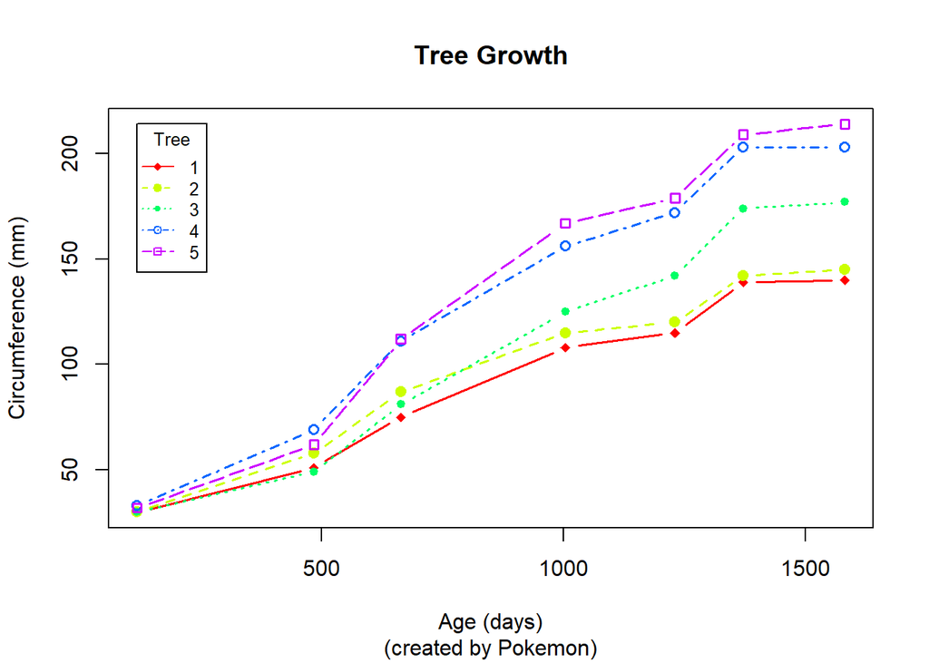

```r
# convert factor to numeric for convenience
Orange$Tree <- as.numeric(Orange$Tree)
ntrees <- max(Orange$Tree)

# get the range for the x and y axis
xrange <- range(Orange$age)
yrange <- range(Orange$circumference)

# set up the plot
plot(xrange, yrange, type="n", xlab="Age (days)",
    ylab="Circumference (mm)" )
colors <- rainbow(ntrees)
linetype <- c(1:ntrees)
plotchar <- seq(18,18+ntrees,1)

# add lines
for (i in 1:ntrees) {
  tree <- subset(Orange, Tree==i)
  lines(tree$age, tree$circumference, type="b", lwd=1.5,
    lty=linetype[i], col=colors[i], pch=plotchar[i])
}

# add a title and subtitle
title("Tree Growth", "(created by Pokemon)")

# add a legend
legend(xrange[1], yrange[2], 1:ntrees, cex=0.8, col=colors,
    pch=plotchar, lty=linetype, title="Tree")
```